# STAT 155 Final Data Analysis Project

A study of house age and house price in Taiwan

Xi, Julia, Chenxin, Lian

12/18/2019 (Section 05)

# Scientific background/motivation

*Research questions*

- Is house age associated with decreased house prices in Taiwan?
- Is house age associated with decreased house prices in Taiwan with latitude as a confounder?
- If there is an association between house age and decreased house-price, is this effect different when the distance to the nearest metro station varies with latitude as a confounder?
- Holding latitude constant, if there is an association between house age and decreased house-price, is this effect different when the number of convenience stores in the living circle varies?

## Description of study/data

- https://archive.ics.uci.edu/ml/datasets/Real+estate+valuation+data+set
- This data set was collected in Taiwan from 2012 to 2013 by Prof. I- Cheng Yeh and was used to build real estate valuation models in his paper (Yeh, I. C., & Hsu, T. K. (2018).
- The data include transaction date, house age (year), distance to the nearest metro station (meter), number of convenience stores in the living circle on foot, latitude (degree), longitude (degree), and house price of unit area (10000 New Taiwan Dollar per Ping, where 1 Ping = 3.3 meters squared).

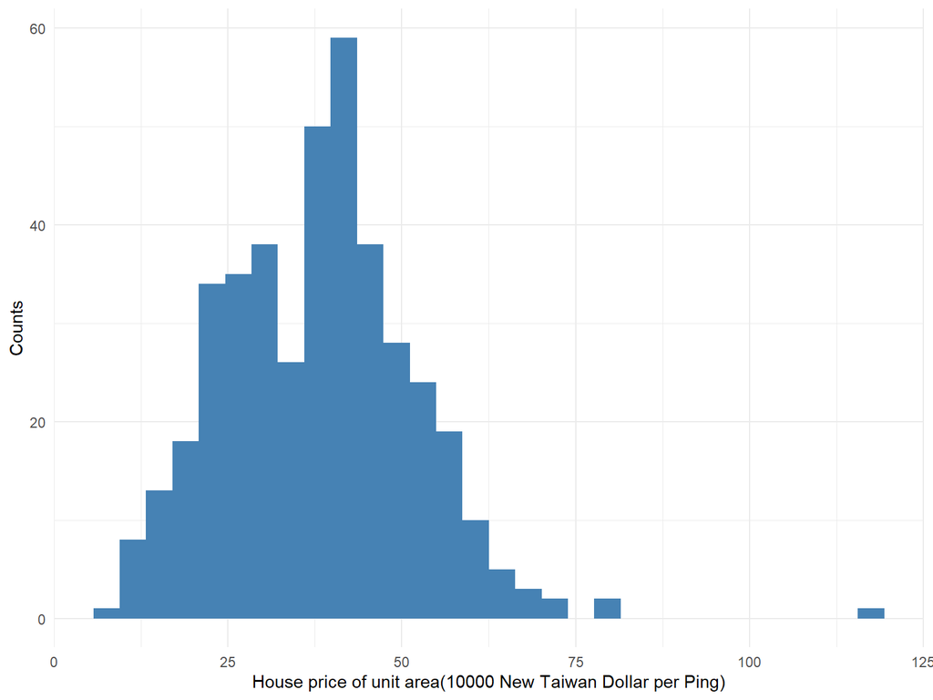

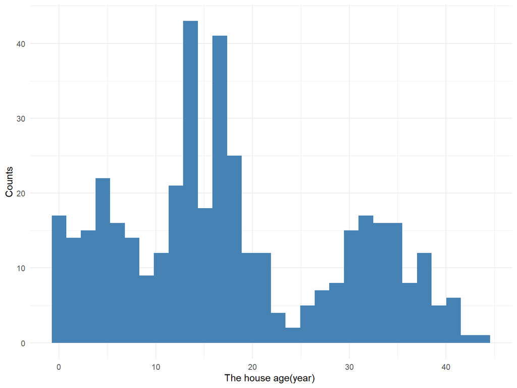

# Question 1

Is house age associated with decreased house prices in Taiwan?

Graph

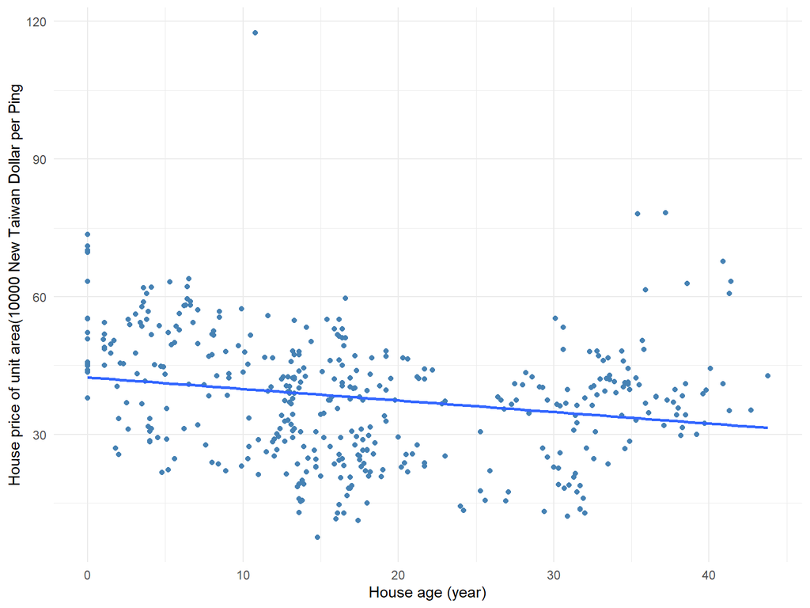

Regression Model

```
##
## Call:
## lm(formula = price ~ age, data = data)
##
## Residuals:
##     Min      1Q  Median      3Q     Max
## -31.113 -10.738   1.626   8.199  77.781
##
## Coefficients:
##             Estimate Std. Error t value Pr(>|t|)
## (Intercept) 42.43470    1.21098  35.042  < 2e-16 ***
## age         -0.25149    0.05752  -4.372 1.56e-05 ***
## ---
## Signif. codes:  0 '***' 0.001 '**' 0.01 '*' 0.05 '.' 0.1 ' ' 1
##
## Residual standard error: 13.32 on 412 degrees of freedom
## Multiple R-squared:  0.04434,    Adjusted R-squared:  0.04202
## F-statistic: 19.11 on 1 and 412 DF,  p-value: 1.56e-05
```

```
##                  2.5 %    97.5 %
## (Intercept) 40.0542333 44.815161
## age         -0.3645609 -0.138416
```

# Question 2

Is house age associated with decreased house prices in Taiwan with latitude as a confounder?

Graph

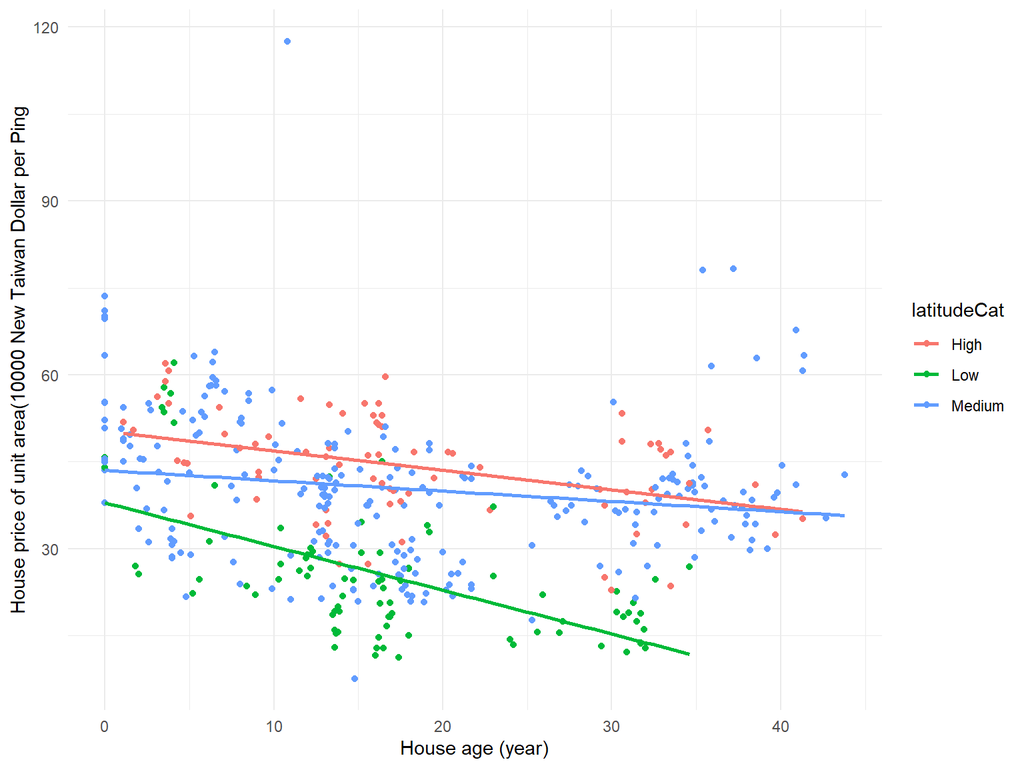

Regression Model

```
##
## Call:
## lm(formula = price ~ age + latitude, data = data)
##
## Residuals:
##     Min      1Q  Median      3Q     Max
## -39.722  -6.731  -1.195   5.598  74.114
##
## Coefficients:
##               Estimate Std. Error t value Pr(>|t|)
## (Intercept) -1.527e+04  1.085e+03 -14.076  < 2e-16 ***
## age         -2.878e-01  4.733e-02  -6.081 2.73e-09 ***
## latitude     6.133e+02  4.345e+01  14.116  < 2e-16 ***
## ---
## Signif. codes:  0 '***' 0.001 '**' 0.01 '*' 0.05 '.' 0.1 ' ' 1
##
## Residual standard error: 10.94 on 411 degrees of freedom
## Multiple R-squared:  0.3564, Adjusted R-squared:  0.3532
## F-statistic: 113.8 on 2 and 411 DF,  p-value: < 2.2e-16
```

```
##                     2.5 %        97.5 %
## (Intercept) -1.740430e+04 -1.313897e+04
## age         -3.808949e-01 -1.948022e-01
## latitude     5.279324e+02  6.987644e+02
```